# Homework 3: Cross-validation and Model Selection

#Installing and loading packages

```r
packages = c('biglm','foreach','doParallel','leaps','caret','knitr')
for(package in packages){
  if(!require(package,character.only=TRUE,quietly=TRUE)){
    install.packages(package,repos='http://cran.us.r-project.org')
    require(package,character.only=TRUE,quietly=TRUE)
  }
}
```

# Problem 1. Out-of-memory Least Squares via biglm (20pts)

An important part of being a statistician is getting comfortable experimenting via simulation. Simulation is the process of generating data from a known distribution. Then, the performance of any procedure(s) can be evaluated/explored precisely due to knowing the truth (which would be unknowable for a data set). Let’s first experiment with fitting the least squares procedure to simulated data.

## Problem 1.1. The full least squares solution

```r
set.seed(1)
n = 4000
p = 500
X = matrix(rnorm(n*p),nrow=n,ncol=p)
format(object.size(X),units='auto')#memory used by X
```

```
## [1] "15.3 Mb"
```

```r
b = rep(0,p)
b[1:5] = 25
Xdf = data.frame(X)
Y = 5 + X %*% b + rnorm(n)
betaHat = coef(lm(Y~X))
betaHat[1:6]
```

```
## (Intercept)          X1          X2          X3          X4          X5
##    4.991328   25.009889   24.992888   24.988658   25.011266   24.995551
```

#### Answer 1.1.

Report the first 5 coefficient estimates and the intercept of the least squares solution

First 5 coefficient estimates: 25.009889, 24.992888, 24.988658, 25.011266, 24.995551 The intercept of the least squares solution: 4.991328

## Problem 1.2. Iteratively updated least squares via biglm

Though this is practically speaking a small problem (see the ‘object.size’ above), let’s pretend it is too large to fit in memory and hence directly using lm is infeasible. The first step is to get the feature matrix into chunks on the hard drive:

```r
write.table(X[1:1000,],file='Xchunk1.txt',sep=',',row.names=F,col.names=names(Xdf))
write.table(X[1001:2000,],file='Xchunk2.txt',sep=',',row.names=F,col.names=names(Xdf))
write.table(X[2001:3000,],file='Xchunk3.txt',sep=',',row.names=F,col.names=names(Xdf))
write.table(X[3001:4000,],file='Xchunk4.txt',sep=',',row.names=F,col.names=names(Xdf))
write.table(Y[1:1000],file='Ychunk1.txt',sep=',',row.names=F,col.names=F)
write.table(Y[1001:2000],file='Ychunk2.txt',sep=',',row.names=F,col.names=F)
write.table(Y[2001:3000],file='Ychunk3.txt',sep=',',row.names=F,col.names=F)
write.table(Y[3001:4000],file='Ychunk4.txt',sep=',',row.names=F,col.names=F)
```

Now, we can read in each chunk individually and update the least squares solution using biglm. This will alleviate the need for reading all of X into memory at the same time. The below code is only partially completed. Complete the procedure in the natural way on the remaining chunks.

```r
# Chunk 1
Xchunk = read.table(file='Xchunk1.txt',sep=',',header=T)
Ychunk = scan(file='Ychunk1.txt',sep=',')
form = as.formula(paste('Ychunk ~ ',paste(names(Xchunk),collapse=' + '),collapse=''))
out.biglm = biglm(formula = form,data=Xchunk)
coef(out.biglm)[1:5]
```

```
## (Intercept)          X1          X2          X3          X4
##    4.970058   25.087823   24.984586   24.948675   25.003253
```

```r
rm(Xchunk)

# Chunk 2
Xchunk = read.table(file='Xchunk2.txt',sep=',',header=T)
Ychunk = scan(file='Ychunk2.txt',sep=',')
out.biglm = update(out.biglm,moredata=Xchunk)
coef(out.biglm)[1:5]
```

```
## (Intercept)          X1          X2          X3          X4
##    4.968055   25.014846   24.980627   24.985553   24.983485
```

```r
rm(Xchunk)

# Chunk 3
Xchunk = read.table(file='Xchunk3.txt',sep=',',header=T)
Ychunk = scan(file='Ychunk3.txt',sep=',')
out.biglm = update(out.biglm,moredata=Xchunk)
coef(out.biglm)[1:5]
```

```
## (Intercept)          X1          X2          X3          X4
##    4.974551   24.999340   24.985498   24.979917   25.009175
```

```r
rm(Xchunk)

#### Answer 1.2.1. Complete the code to complete the update

# Chunk 4
Xchunk = read.table(file='Xchunk4.txt',sep=',',header=T)
Ychunk = scan(file='Ychunk4.txt',sep=',')
out.biglm = update(out.biglm,moredata=Xchunk)
coef(out.biglm)[1:5]
```

```
## (Intercept)          X1          X2          X3          X4
##    4.991328   25.009889   24.992888   24.988658   25.011266
```

```r
rm(Xchunk)
```

#### Answer 1.2.2

Compare the first 5 non-intercept entries in betaHat to the cofficient estimate . What is the advantage of computing the coefficient estimates via biglm versus lm?

They have the same cofficient estimate, but the biglm could help alleviate the loading of the memory.

# Problem 2. Cross Validation and Parallelism (30 pts)

## Problem 2.1. Simple example of parallelism

First, let’s explore parallelism in R. Parallelism can be used to speed up computations by using multiple processors/CPUs at the same time. It is especially useful if we need to run a lot of computations at the same time that don’t depend on eachother (this is often called “trivially” or “embarrassingly” parallel)

Note: The -1 in the “nCores” below is if using a GUI and hence needing system resources for other than processing. Usually, parallel processing is meant to be run in ``batch’’ mode (R CMD BATCH myRscript.r &) though we won’t be running in batch for this assignment.

```r
nCores  = detectCores(all.tests = FALSE, logical = TRUE) - 1
cat('My work station has ',nCores,' cores \n')
```

```
## My work station has  3  cores
```

```r
cl = makeCluster(nCores)
registerDoParallel(cl)

tmp  = rep(.1,nCores*10)
wait = function(tmp_i) Sys.sleep(tmp_i)
system.time(sapply(tmp,wait))#single processor
```

```
##    user  system elapsed
##   0.004   0.001   3.096
```

```r
system.time(foreach(tmp_i = tmp) %dopar% {wait(tmp_i)})#parallel
```

```
##    user  system elapsed
##   0.042   0.004   1.194
```

#### Answer 2.1.1

Comment on the relative sizes of nCores vs. the system.time with and without parallelism (note that if you happen to have a 2 core or fewer work station, you won’t see any difference. If you have 2 cores, try and eliminate the ‘-1’ from the code above)

The system.time with paralleism is much less than the system.time without paralleism. As I have 3 cores, the system.time without paralleism is about 3 times than the system.time with paralleism.

## Problem 2.2. Cross-Validation

Now, we want to implement our own K- Fold CV and apply it to the simulated data from the previous question.

```r
K        = 10
folds    = sample(rep(1:K, length.out = n)) #data
CVoutput = rep(0,K)

for(k in 1:K){
  validIndex  = which(folds == k)
  betaHatNok  = coef(lm(Y~X,subset=-validIndex))
  YhatValid   = betaHatNok[1] + X[validIndex,] %*% betaHatNok[-1]
  CVoutput[k] = (1/(n/K))*sum((Y[validIndex]-YhatValid)^2)#### Answer 2.2.1

}

cat('CV estimate of the risk: ',mean(CVoutput),'\n')
```

```
## CV estimate of the risk:  1.171231
```

```r
cat('Standard error of CV estimate of the risk: ',sd(CVoutput)/sqrt(K),'\n')
```

```
## Standard error of CV estimate of the risk:  0.02930568
```

#### Answer 2.2.2.

What could the standard error of CV estimate be used for?

We could employ one standard error rule by the standard error of CV estimate. One standard error rule is a rule for choosing the value of the tuning parameters. It helps us pick up a more regularized model.

## Problem 2.3. Cross-validation in Parallel

CV runs well in parallel, so let’s try that out. First, let’s define a function:

```r
cvF = function(k ,folds){
  #CVoutput = rep(0,K)
  #folds    = sample(rep(1:K, length.out = n))
  #for(k in 1:K){
  validIndex  = which(folds == k)
  betaHatNok  = coef(lm(Y~X,subset=-validIndex))
  YhatValid   = betaHatNok[1] + X[validIndex,] %*% betaHatNok[-1]
  CVoutput = sum((Y[validIndex]-YhatValid)^2)/length(validIndex)#### Answer 2.2.1
  return(CVoutput)

}
  #### Answer 2.3.1.  Complete this function
```

Now, we want to extend the above parallel code to CV. If we use ‘dopar’, then we will be using the parallel backend we defined earlier. If we use ‘do’, this is just another way of writing a for loop in R and it won’t use the parallel backend (i.e. it will be doing sequential processing)

```r
startTime        = proc.time()[3]
CVoutputParallel = foreach(k = 1:K) %dopar%{cvF(k, folds)}
endTime          = proc.time()[3]
parallelTime     = endTime-startTime
parallelCV       = mean(CVoutput)


startTime          = proc.time()[3]
CVoutputSequential = foreach(k = 1:K) %do%{cvF(k, folds)}
endTime            = proc.time()[3]
seqTime            = endTime-startTime
seqCV              = mean(CVoutput)


parallelTime
```

```
## elapsed
##   6.961
```

```r
seqTime
```

```
## elapsed
##  14.714
```

```r
parallelCV
```

```
## [1] 1.171231
```

```r
seqCV
```

```
## [1] 1.171231
```

#### Answer 2.3.1.

Compare the time for CV and the values of the K-fold CV estimator of the risk with and without parallelism

Parallel time is 0.4730869 times as long as the sequential time. The parallel CV estimate is 1.1712313 while the sequential CV estimate is 1.1712313. These are the same.

## Problem 2.4. Let’s look at the CV estimate of the risk as a function of K.

Also, make a plot of the CV estimate of the risk for a variety of K values (note that LOOCV would be of interest, but would take awhile on this problem):

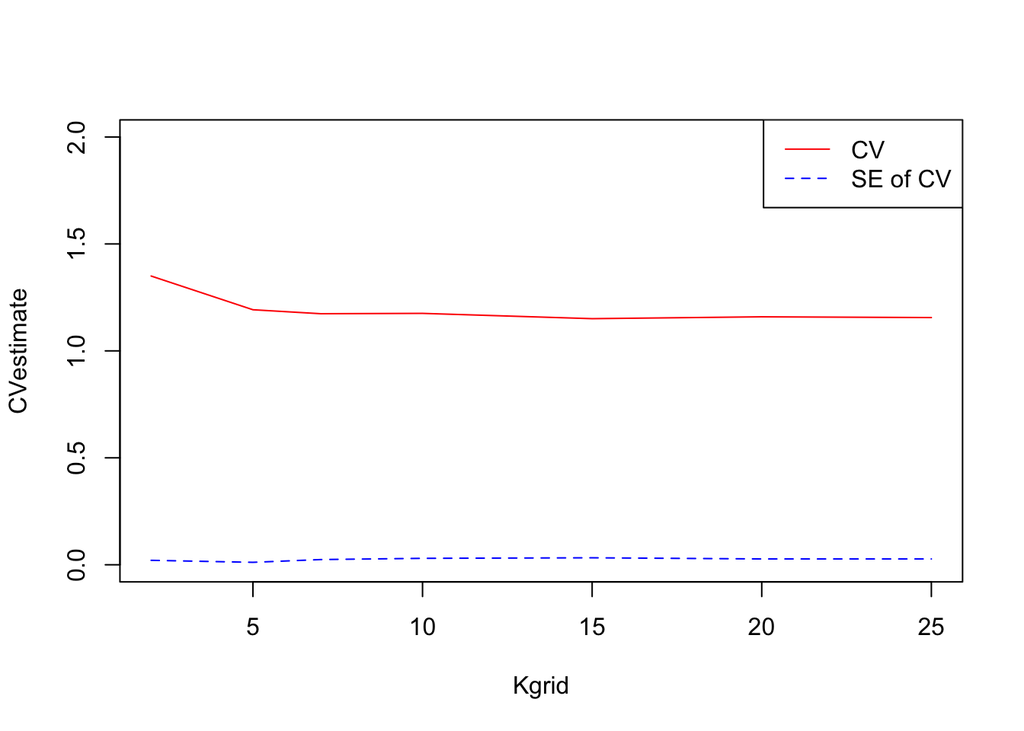

```r
Kgrid      = c(2,5,7,10,15,20,25)
CVestimate = rep(0,length(Kgrid))
CVse       = rep(0,length(Kgrid))
Kiter      = 0
for(K in Kgrid){
  Kiter             = Kiter + 1
  folds             = sample(rep(1:K, length.out = n))
  CVestimateVec     = unlist(foreach(k = 1:K) %dopar%{cvF(k, folds)})
  CVestimate[Kiter] = mean(CVestimateVec)
  CVse[Kiter]       = sd(CVestimateVec)/sqrt(K)
}

plot(Kgrid, CVestimate,
     col='red', type='l', ylim=c(0,2))
lines(Kgrid, CVse,
      col='blue', lty=2)
legend(x='topright', legend=c('CV','SE of CV'),
       lty=1:2, col=c('red','blue'))
```

#### Answer 2.4.1.

In general, what is the relationship between K & Risk? What aspects of this relationship are represented in this plot?

The risk becomes lower while K is bigger. However, as we can see, the results of CV estimates are similar after K = 5. Though we could have a big number of K to have a lower CV estimate, but that may result in time consuming. Thus, choosing a proper K is an important work for K-fold cross validation.

## Problem 2.5. Cross-validation in Caret

The [caret](https://cran.r-project.org/web/packages/caret/vignettes/caret.pdf) package can do some commonly done statistical learning tasks for you. In particular, create the folds:

```r
folds = createFolds(Y, k = K, list = TRUE)
```

#### Answer 2.5.1.

What ‘folds’ object (this one or the previous one we defined earlier) more directly matches the definition of K-fold CV from the lectures?

The previous one is more directly matches the definition of K-fold CV from the lectures since we used stratified splitting for K-fold CV in the lectures.

It’s best practice to stop the cluster when you’re done with parallel computing and return to sequential computing

```r
stopCluster(cl)
registerDoSEQ()
```

# Problem 3. Forward Selection (20 pts)

Using the same simulated X and Y generated in the previous problem, use forward selection and K-fold CV to form an estimate betaHat. Let’s get a training/test split so we can get different estimators of the risk.

## Problem 3.1.

We can use caret for doing the data splitting:

```r
trainingIndex = createDataPartition(Y, p = 0.5, list = FALSE)

Xdf = data.frame(X)

Xtrain = Xdf[trainingIndex,]
Xtest  = Xdf[-trainingIndex,]
Ytrain = Y[trainingIndex]
Ytest  = Y[-trainingIndex]
```

and the training:

```r
K          = 10
trControl  = trainControl(method = 'cv', number = K)
tuneLength = 50
lmOut      = train(x = Xtrain, y = Ytrain,
                  method = "leapForward", tuneLength = tuneLength,
                  trControl = trControl)
```

#### Answer 3.1.1

What does ‘tuneLength’ do in this function in terms of forward selection (be specific)?

In forward selection, we add variables one by one to get a proper model. The ‘tuneLength’ tells the algorithm to try different default values for the nvmax in this case. Nvmax specifies the maximal number of predictors to incorporate in the model. Therefore, ‘tuneLength’ could help us test different numbers of predictors in forward selection.

## Problem 3.2. Getting the risk estimate minimizing solution

Using BIC (which makes sense as we are interested in selecting the correct model), select the BIC minimizing solution

```r
numSelectedCoefs = lmOut$bestTune$nvmax

betaHatForward   = coef(lmOut$finalModel, numSelectedCoefs)
betaHatForward
```

```
## (Intercept)          X1          X2          X3          X4          X5
##  5.00643467 25.01737213 24.98151291 25.01889047 24.98365936 24.96904517
##         X71        X281        X361        X390        X404
## -0.07491519  0.08567222  0.07842813  0.06767017 -0.08140254
```

## Problem 4. Comparing risk estimates (30 pts)

Compare the training error, K-fold CV, and test error for both the least squares solution and the forward selection solution. Look into [train](https://topepo.github.io/caret/model-training-and-tuning.html) for more information about using ‘train’ and its output. In particular, the output of train has an object ‘resample’ which contains the square root of the loss evaluated on each fold, which it calls RMSE for ‘ root mean square error’.

```r
lmOutLeastSq = train(x = Xtrain, y = Ytrain,
                    method = "lm", trControl = trControl)
YhatLS       = predict(lmOutLeastSq, Xtrain)
YhatTestLS   = predict(lmOutLeastSq, Xtest)#### Answer. 4.1

leastSquaresResults = data.frame('trainingError' = mean( (YhatLS - Ytrain)**2 ),
                                 'KfoldCV'       = mean( lmOutLeastSq$resample$RMSE**2 ),
                                 'testError'     = mean((YhatTestLS - Ytest)**2)) #### Answer. 4.2


YhatForward      = predict(lmOut, Xtrain) #### Answer. 4.3
YhatTestForward  = predict(lmOut, Xtest)#### Answer. 4.4

forwardResults      = data.frame('trainingError' = mean((YhatForward - Ytrain)**2), #### Answer. 4.5
                                 'KfoldCV'       = mean(lmOut$resample$RMSE**2), #### Answer. 4.6
                                 'testError'     = mean((YhatTestForward - Ytest)**2)) #### Answer. 4.7


results = rbind(leastSquaresResults, forwardResults)

kable(results, caption = 'Comparison of least squares and forward selection')
```

Comparison of least squares and forward selection

| trainingError | KfoldCV | testError |
| --- | --- | --- |
| 0.7822298 | 1.423220 | 1.338308 |
| 0.9944821 | 1.014205 | 1.034020 |

#### Answer 4.8

In no more than 2 sentences, discuss this table.

As least squares has higher Kfold CV, it has higher bias. Thus, the difference between training error and test error is larger than forward’s.